# BST 260 Final Project: Cleaning Physician Compare National Data File

Eunice Yeh

# Purpose

1. explore the data and summarize key variables
2. clean/reduce data: decide which rows and columns to filter out

## 1. Exploratory Analysis

Import data from `.csv` file, downloaded from the (Medicare Data website)[https://data.medicare.gov/Physician-Compare/Physician-Compare-National-Downloadable-File/].

```r
dat <- read.csv("Physician_Compare_National_Downloadable_File.csv")
```

Quick look at the data structure.

```r
str(dat)
```

```
## 'data.frame':    2254703 obs. of  41 variables:
##  $ NPI                                                               : int  1487927612 1235146762 1285727842 1295821098 1063514289 1346282258 1932283124 1902950462 1518981026 1972698736 ...
##  $ PAC.ID                                                            : num  4.88e+09 2.37e+09 5.80e+09 8.40e+08 1.95e+09 ...
##  $ Professional.Enrollment.ID                                        : Factor w/ 1097398 levels "I20031103000001",..: 728301 36112 70336 705014 51466 226540 152754 691087 615054 52822 ...
##  $ Last.Name                                                         : Factor w/ 247404 levels "A'BELLE","AABERG",..: 88758 238018 36122 149543 141638 49619 33364 65477 170605 102311 ...
##  $ First.Name                                                        : Factor w/ 70186 levels "A","A'LANNE",..: 17121 6246 38335 25660 65362 27834 59268 34230 12507 24343 ...
##  $ Middle.Name                                                       : Factor w/ 21391 levels "","'CATHY'","'JILL'",..: 16800 10724 16800 6115 1 10 6115 7464 11908 1 ...
##  $ Suffix                                                            : Factor w/ 12 levels "","I","II","III",..: 1 1 1 1 1 1 1 1 1 1 ...
##  $ Gender                                                            : Factor w/ 3 levels "F","M","U": 1 1 2 1 2 2 2 1 2 1 ...
##  $ Credential                                                        : Factor w/ 22 levels "","AA","AU","CNA",..: 1 8 9 1 16 8 9 1 1 14 ...
##  $ Medical.school.name                                               : Factor w/ 406 levels "A T STILL UN, ARIZONA SCHL OF DENT.Y & ORAL HLTH",..: 134 220 220 214 220 220 239 133 220 220 ...
##  $ Graduation.year                                                   : int  2010 1992 1981 1984 1997 1999 1997 1985 1976 1990 ...
##  $ Primary.specialty                                                 : Factor w/ 80 levels "","ADDICTION MEDICINE",..: 12 15 12 19 48 15 12 12 12 36 ...
##  $ Secondary.specialty.1                                             : Factor w/ 64 levels "","ADDICTION MEDICINE",..: 1 1 1 1 1 1 1 1 1 1 ...
##  $ Secondary.specialty.2                                             : Factor w/ 61 levels "","ALLERGY/IMMUNOLOGY",..: 1 1 1 1 1 1 1 1 1 1 ...
```

[output cut: 27 more lines]

Load `tidyverse` package for data wrangling and plotting functions.

```r
library(tidyverse)
```

Look at the distribution of physician graduation year by physician credentials and by use of EHR.

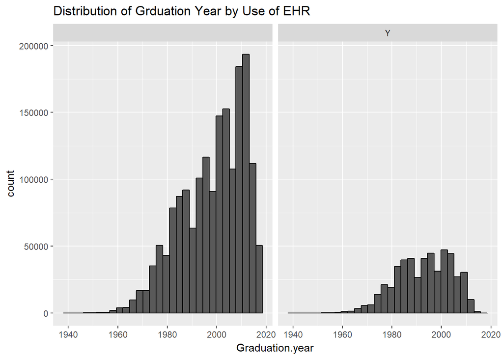

```r
gradyr <- dat %>% filter(!is.na(Graduation.year)) %>%
  group_by(Credential, Used.electronic.health.records)

gradyr %>%
  ggplot(aes(Graduation.year)) +
  geom_histogram(color = "black") +
  facet_grid(.~Used.electronic.health.records) +
  ggtitle("Distribution of Grduation Year by Use of EHR")
```

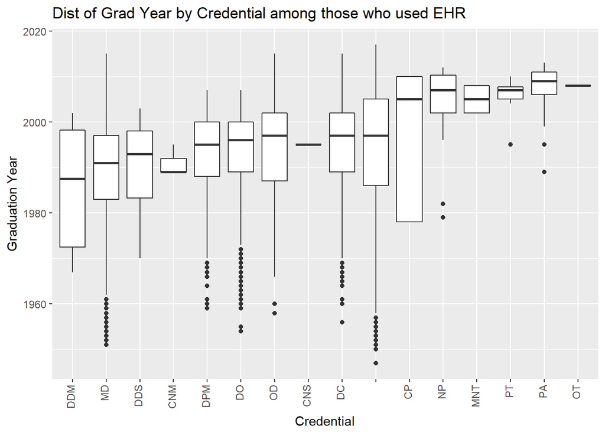

```r
gradyr %>% filter(Used.electronic.health.records == 'Y') %>%
  ungroup() %>%
  mutate(Credential = reorder(Credential, Graduation.year)) %>%
  ggplot(aes(factor(Credential), Graduation.year)) +
  geom_boxplot() +
  # scale_y_continuous(trans = "sqrt", breaks = seq(0, 100, 2)^2) +
  theme(axis.text.x = element_text(angle = 90, hjust = 1, vjust = 0.25)) +
  xlab("Credential") +
  ylab("Graduation Year") +
  ggtitle("Dist of Grad Year by Credential among those who used EHR")
```

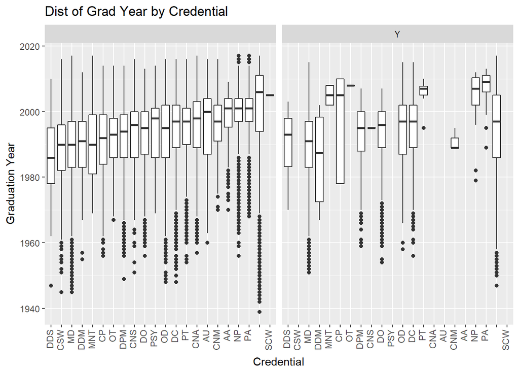

```r
gradyr %>%
  ungroup() %>%
  mutate(Credential = reorder(Credential, Graduation.year)) %>%
  ggplot(aes(factor(Credential), Graduation.year)) +
  geom_boxplot() +
  facet_grid(.~Used.electronic.health.records) +
  # scale_y_continuous(trans = "sqrt", breaks = seq(0, 100, 2)^2) +
  theme(axis.text.x = element_text(angle = 90, hjust = 1, vjust = 0.25)) +
  xlab("Credential") +
  ylab("Graduation Year") +
  ggtitle("Dist of Grad Year by Credential")
```

Look at the distribution of physician graduation year by US States separately for those who used EHR and for those who have not indicated using EHR.

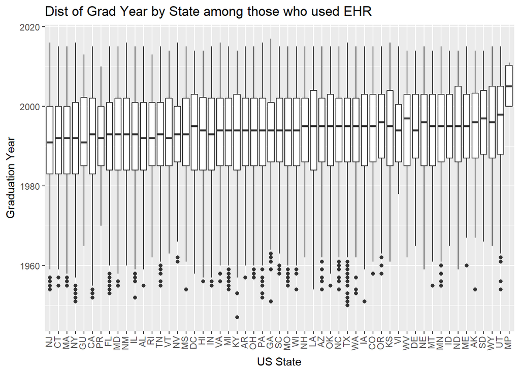

```r
# for those who used EHR
gradyr %>% ungroup() %>% filter(Used.electronic.health.records == 'Y') %>%
  mutate(State = reorder(State, Graduation.year)) %>%
  ggplot(aes(factor(State), Graduation.year)) +
  geom_boxplot() +
  # facet_grid(.~Used.electronic.health.records) +
  # scale_y_continuous(trans = "sqrt", breaks = seq(0, 100, 2)^2) +
  theme(axis.text.x = element_text(angle = 90, hjust = 1, vjust = 0.25)) +
  xlab("US State") +
  ylab("Graduation Year") +
  ggtitle("Dist of Grad Year by State among those who used EHR")
```

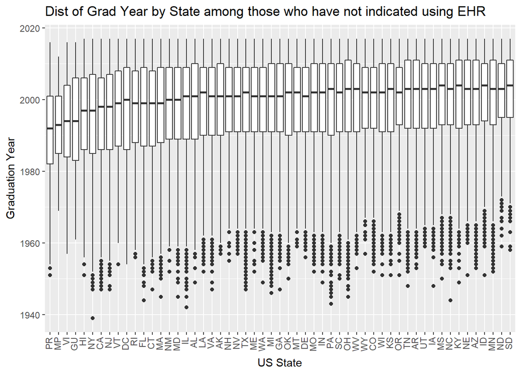

```r
# for those who did not indicate having used EHR
gradyr %>% ungroup() %>% filter(Used.electronic.health.records != 'Y') %>%
  mutate(State = reorder(State, Graduation.year)) %>%
  ggplot(aes(factor(State), Graduation.year)) +
  geom_boxplot() +
  # facet_grid(.~Used.electronic.health.records) +
  # scale_y_continuous(trans = "sqrt", breaks = seq(0, 100, 2)^2) +
  theme(axis.text.x = element_text(angle = 90, hjust = 1, vjust = 0.25)) +
  xlab("US State") +
  ylab("Graduation Year") +
  ggtitle("Dist of Grad Year by State among those who have not indicated using EHR")
```

```r
rm(gradyr) # removing after use to save space
```

Calculate the proportion of EHR use by State.

```r
EHR_bystate <- dat %>%
  group_by(State) %>%
  summarize(EHR_count = sum(Used.electronic.health.records == 'Y'), total = n(),
            EHR_prop = EHR_count/total)
EHR_bystate
```

```
## # A tibble: 55 x 4
##     State EHR_count  total   EHR_prop
##    <fctr>     <int>  <int>      <dbl>
##  1     AK       469   5715 0.08206474
##  2     AL      4980  24157 0.20615143
##  3     AR      3624  16506 0.21955652
##  4     AZ      7841  53172 0.14746483
##  5     CA     37554 194293 0.19328540
##  6     CO      8951  44292 0.20209067
##  7     CT      5612  28052 0.20005704
##  8     DC      1377   6074 0.22670398
##  9     DE      2189   9615 0.22766511
## 10     FL     29943 123961 0.24155178
## # ... with 45 more rows
```

Plot the proportion of EHR use by State.

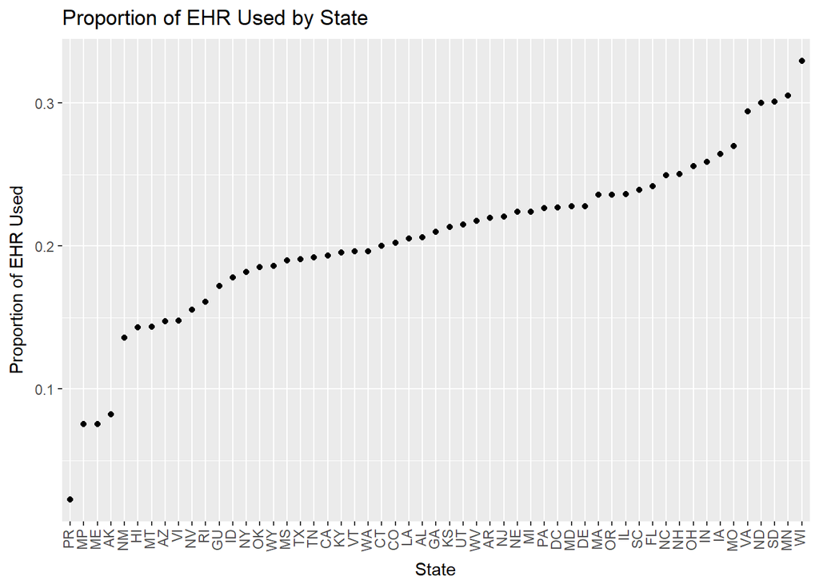

```r
EHR_bystate %>% mutate(State = reorder(State, EHR_prop)) %>%
  ggplot(aes(factor(State), EHR_prop)) +
  geom_point() +
  theme(axis.text.x = element_text(angle = 90, hjust = 1, vjust = 0.25)) +
  xlab("State") +
  ylab("Proportion of EHR Used") +
  ggtitle("Proportion of EHR Used by State")
```

```r
rm(EHR_bystate)
```

Calculate the percentage of EHR use by Primary Specialty and by State. – consider filterning out n() < 50 or 100?

```r
EHR_primspec_bystate <- dat %>%
  filter(!is.na(Graduation.year)) %>%
  group_by(State, Primary.specialty) %>%
  summarize(EHR_count = sum(Used.electronic.health.records == 'Y'), total = n(), EHR_percent = EHR_count/total * 100) %>%
  mutate(Primary.specialty = reorder(Primary.specialty, EHR_percent))
EHR_primspec_bystate
```

```
## # A tibble: 3,907 x 5
## # Groups:   State [55]
##     State                      Primary.specialty EHR_count total
##    <fctr>                                 <fctr>     <int> <int>
##  1     AK                     ADDICTION MEDICINE         0     8
##  2     AK                     ALLERGY/IMMUNOLOGY         2    15
##  3     AK                         ANESTHESIOLOGY         6   180
##  4     AK                            AUDIOLOGIST         0    42
##  5     AK              CARDIAC ELECTROPHYSIOLOGY         2    14
##  6     AK                        CARDIAC SURGERY         0     4
##  7     AK    CARDIOVASCULAR DISEASE (CARDIOLOGY)        45   105
##  8     AK                CERTIFIED NURSE MIDWIFE         0    48
##  9     AK CERTIFIED REGISTERED NURSE ANESTHETIST         0   104
## 10     AK                           CHIROPRACTIC        12   259
## # ... with 3,897 more rows, and 1 more variables: EHR_percent <dbl>
```

Plot the percentage of EHR use by Primary Specialty and by State.

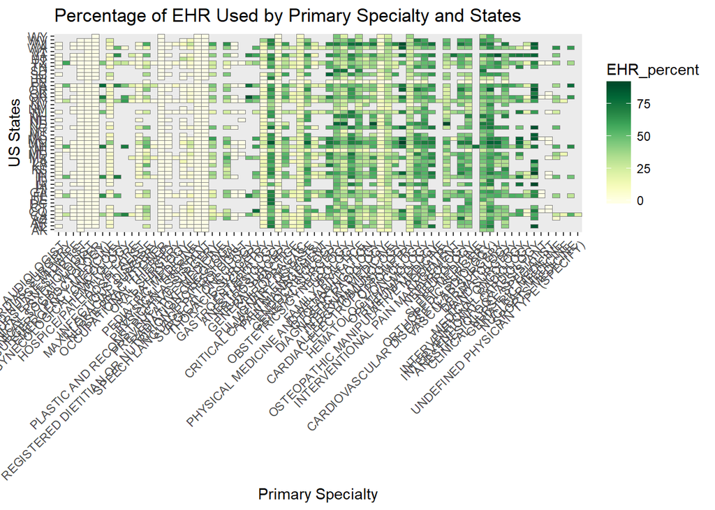

```r
library(RColorBrewer)
EHR_primspec_bystate %>% filter(total > 100) %>%
  ggplot(aes(Primary.specialty, State,  fill = EHR_percent)) +
  geom_tile(color = "grey50") +
  # scale_x_continuous(expand=c(0,0)) +
  theme(axis.text.x = element_text(angle = 45, hjust = 1, vjust = 1)) +
  scale_fill_gradientn(colors = brewer.pal(9, "YlGn")) +
  theme(panel.grid = element_blank()) +
  ylab("US States") +
  xlab("Primary Specialty") +
  ggtitle("Percentage of EHR Used by Primary Specialty and States")
```

```r
rm(EHR_primspec_bystate)
```

## 2. Data Cleaning Decisions:

1. filter out states outside of the main 50 except for DC since there is not a lot of information in those states and the other data we want to merge with do not contain information on these states anyway.

```r
unique(dat$State)
```

```
##  [1] CA NJ NM NY NC GA TX PR WI FL WA OH VA AZ IL PA MI OR ME MN RI VT LA
## [24] MA IA MD UT NV TN SC NH CO KY CT AL WV DE OK MT DC SD NE IN WY KS MS
## [47] ND MO HI ID AR GU AK VI MP
## 55 Levels: AK AL AR AZ CA CO CT DC DE FL GA GU HI IA ID IL IN KS KY ... WY
```

```r
data("state")
new_dat <- dat[dat$State %in% unique(state.abb) == "TRUE" | dat$State == "DC", ]
unique(new_dat$State)
```

```
##  [1] CA NJ NM NY NC GA TX WI FL WA OH VA AZ IL PA MI OR ME MN RI VT LA MA
## [24] IA MD UT NV TN SC NH CO KY CT AL WV DE OK MT DC SD NE IN WY KS MS ND
## [47] MO HI ID AR AK
## 55 Levels: AK AL AR AZ CA CO CT DC DE FL GA GU HI IA ID IL IN KS KY ... WY
```

2. (TAKE THIS OUT LATER) keep only rows with `Professional.accepts.Medicare.Assignment = 'Y'` since we are only interested in practioners who have definitely accepted medicare assignments, and we need to merge with other data that only contain those serving Medicare.

```r
rm(dat) # removing previous data to save space and speed up run time
table(new_dat$Professional.accepts.Medicare.Assignment)
```

```
##
##       M       Y
##   94208 2149535
```

```r
filtered_dat <- new_dat %>% filter(Professional.accepts.Medicare.Assignment == 'Y')
table(filtered_dat$Professional.accepts.Medicare.Assignment)
```

```
##
##       M       Y
##       0 2149535
```

```r
filtered_dat <- new_dat
rm(new_dat)
# easier to exclude than to type out all the variables to include
select_dat <- filtered_dat %>% select(-PAC.ID, -Professional.Enrollment.ID, -Middle.Name, -Suffix, -Group.Practice.PAC.ID, -Line.1.Street.Address, -Line.2.Street.Address, -Marker.of.address.line.2.suppression, -Phone.Number, -Professional.accepts.Medicare.Assignment, -Reported.Quality.Measures, -Committed.to.heart.health.through.the.Million.HeartsÂ..initiative.)
str(select_dat)
```

```
## 'data.frame':    2243743 obs. of  29 variables:
##  $ NPI                             : int  1487927612 1235146762 1285727842 1295821098 1063514289 1346282258 1932283124 1902950462 1518981026 1972698736 ...
##  $ Last.Name                       : Factor w/ 247404 levels "A'BELLE","AABERG",..: 88758 238018 36122 149543 141638 49619 33364 65477 170605 102311 ...
##  $ First.Name                      : Factor w/ 70186 levels "A","A'LANNE",..: 17121 6246 38335 25660 65362 27834 59268 34230 12507 24343 ...
##  $ Gender                          : Factor w/ 3 levels "F","M","U": 1 1 2 1 2 2 2 1 2 1 ...
##  $ Credential                      : Factor w/ 22 levels "","AA","AU","CNA",..: 1 8 9 1 16 8 9 1 1 14 ...
##  $ Medical.school.name             : Factor w/ 406 levels "A T STILL UN, ARIZONA SCHL OF DENT.Y & ORAL HLTH",..: 134 220 220 214 220 220 239 133 220 220 ...
##  $ Graduation.year                 : int  2010 1992 1981 1984 1997 1999 1997 1985 1976 1990 ...
##  $ Primary.specialty               : Factor w/ 80 levels "","ADDICTION MEDICINE",..: 12 15 12 19 48 15 12 12 12 36 ...
##  $ Secondary.specialty.1           : Factor w/ 64 levels "","ADDICTION MEDICINE",..: 1 1 1 1 1 1 1 1 1 1 ...
##  $ Secondary.specialty.2           : Factor w/ 61 levels "","ALLERGY/IMMUNOLOGY",..: 1 1 1 1 1 1 1 1 1 1 ...
##  $ Secondary.specialty.3           : Factor w/ 55 levels "","CARDIOVASCULAR DISEASE (CARDIOLOGY)",..: 1 1 1 1 1 1 1 1 1 1 ...
##  $ Secondary.specialty.4           : Factor w/ 44 levels "","CRITICAL CARE (INTENSIVISTS)",..: 1 1 1 1 1 1 1 1 1 1 ...
##  $ All.secondary.specialties       : Factor w/ 1505 levels "","ADDICTION MEDICINE",..: 1 1 1 1 1 1 1 1 1 1 ...
##  $ Organization.legal.name         : Factor w/ 175961 levels "","'A' STREET CLINIC OF CHIROPRACTIC, PLLC",..: 1 1 26930 150874 1 1 23914 1 1 110503 ...
##  $ Number.of.Group.Practice.members: int  NA NA 2 6 NA NA 2 NA NA 2 ...
##  $ City                            : Factor w/ 10963 levels "20850","ABBEVILLE",..: 7682 2928 3020 83 8677 793 1037 8361 134 567 ...
##  $ State                           : Factor w/ 55 levels "AK","AL","AR",..: 5 34 5 35 37 37 30 11 47 37 ...
##  $ Zip.Code                        : Factor w/ 228197 levels "000075949","00079",..: 217703 18302 217452 194105 37173 39321 69238 76918 181325 31861 ...
##  $ Hospital.affiliation.CCN.1      : Factor w/ 4760 levels "","010001","010005",..: 1 1 1 1 1 1 1 1 1 1 ...
##  $ Hospital.affiliation.LBN.1      : Factor w/ 4529 levels "","ABBEVILLE AREA MEDICAL CENTER",..: 1 1 1 1 1 1 1 1 1 1 ...
##  $ Hospital.affiliation.CCN.2      : Factor w/ 4726 levels "","010001","010005",..: 1 1 1 1 1 1 1 1 1 1 ...
##  $ Hospital.affiliation.LBN.2      : Factor w/ 4492 levels "","ABBEVILLE AREA MEDICAL CENTER",..: 1 1 1 1 1 1 1 1 1 1 ...
##  $ Hospital.affiliation.CCN.3      : Factor w/ 4691 levels "","010001","010005",..: 1 1 1 1 1 1 1 1 1 1 ...
##  $ Hospital.affiliation.LBN.3      : Factor w/ 4460 levels "","ABBEVILLE AREA MEDICAL CENTER",..: 1 1 1 1 1 1 1 1 1 1 ...
##  $ Hospital.affiliation.CCN.4      : Factor w/ 4640 levels "","010001","010005",..: 1 1 1 1 1 1 1 1 1 1 ...
##  $ Hospital.affiliation.LBN.4      : Factor w/ 4413 levels "","ABBEVILLE AREA MEDICAL CENTER",..: 1 1 1 1 1 1 1 1 1 1 ...
##  $ Hospital.affiliation.CCN.5      : int  NA NA NA NA NA NA NA NA NA NA ...
##  $ Hospital.affiliation.LBN.5      : Factor w/ 4345 levels "","ABBEVILLE AREA MEDICAL CENTER",..: 1 1 1 1 1 1 1 1 1 1 ...
##  $ Used.electronic.health.records  : Factor w/ 2 levels "","Y": 1 1 1 1 1 1 1 1 1 1 ...
```

4. merge in accurate city, state, latitude, longitude information by zip codes using the `zipcode` package.

```r
rm(filtered_dat)
# separate out the first five zip codes from the last four extension to match R zipcode data
zip_dat <- select_dat %>% mutate(zip = substr(as.character(Zip.Code), 1, 5), zip.ext = substr(as.character(Zip.Code), 6, 9))

# use R zipcode package and data
library(zipcode)
data("zipcode")
zip_dat <- zip_dat %>% left_join(zipcode,by='zip')
zip_dat %>% select(NPI, Zip.Code, zip, zip.ext, City, State, city, state, latitude, longitude) %>% head(.,20)
```

```
##           NPI  Zip.Code   zip zip.ext           City State        city
## 1  1487927612 956673933 95667    3933    PLACERVILLE    CA Placerville
## 2  1235146762 076312530 07631    2530      ENGLEWOOD    NJ   Englewood
## 3  1285727842 956283541 95628    3541      FAIR OAKS    CA   Fair Oaks
## 4  1295821098 871101437 87110    1437    ALBUQUERQUE    NM Albuquerque
## 5  1063514289 124771804 12477    1804     SAUGERTIES    NY  Saugerties
## 6  1346282258 139015821 13901    5821     BINGHAMTON    NY  Binghamton
## 7  1932283124 287129524 28712    9524        BREVARD    NC     Brevard
## 8  1902950462 307411348 30741    1348      ROSSVILLE    GA   Rossville
## 9  1518981026 798304607 79830    4607         ALPINE    TX      Alpine
## 10 1972698736 113611117 11361    1117        BAYSIDE    NY     Bayside
## 11 1598766461 142221202 14222    1202        BUFFALO    NY     Buffalo
## 12 1477630564 545013314 54501    3314    RHINELANDER    WI Rhinelander
## 13 1114092335 113734245 11373    4245       ELMHURST    NY    Elmhurst
## 14 1104865484 336176214 33617    6214 TEMPLE TERRACE    FL       Tampa
```

[output cut: 27 more lines]

Check mismatched state between our data and the zipcode data from R.

```r
rm(select_dat)

# look up top 10 records with state mismatches
zip_mismatch <- zip_dat %>%
  mutate(State = as.character(State), state = as.character(state)) %>%
  filter(State != state) %>%
  select(NPI, zip, City, city, State, state) %>%
  group_by(zip, City, State, city, state) %>%
  summarize(n = n()) %>%
  arrange(desc(n)) %>%
  head(5)
zip_mismatch
```

```
## # A tibble: 5 x 6
## # Groups:   zip, City, State, city [5]
##     zip           City State           city state     n
##   <chr>         <fctr> <chr>          <chr> <chr> <int>
## 1 99362    WALLA WALLA    WA    Walla Walla    OR   346
## 2 52761      MUSCATINE    IA      Muscatine    IL   176
## 3 43530        GRANGER    IN         Jewell    OH   140
## 4 22401 FREDERICKSBURG    MD Fredericksburg    VA   131
## 5 20176        HANOVER    MD       Leesburg    VA   106
```

In order to not just blatantly throw away the mismatches, we will look at the top 5 most common mismatches on a case-by-case basis to try to salvage as many records as possible without searching too deeply in our dataset. Also, starting from the 6th most common mismatches, the number of records (n) were down to 58 or less, so they would have little effect on the dataset.